# Predictive modeling: Advanced Regression Techniques

Iryna Pazharytskaya

28 de mayo de 2018

## Introduction.

In my project I am going to analyze data in order to help provide insight into the housing market of Ames, Iowa and create a model to predict housing prices based on its features. That would help a real estate company make decisions on how to invest for highest profits. The main idea is to make money for the investors, and therefore being able to identify which properties are overvalued and which are undervalued are crucial for Real Estate Business.

## Data.

The `AmesHousing` data set provides housing sales from between 2006 to 2010 and contains variables focused on the quality and quantity of many physical attributes of the property. Most of the variables are exactly the type of information that a typical home buyer would want to know about a potential property, such as the year it was built, the size of the lot, the numbers of rooms, square feet of living space, as well as the neighborhood, utilities, etc.

There are **2930 observations** and **80 variables**:

- **20 continuous variables** related to various area dimensions for each observation.
- **14 discrete variables** typically quantify the number of items occurring within the house.
- **46 categorical variables** (23 nominal, 23 ordinal). They range from 2 to 28 classes with the smallest being `Street` (gravel or paved) and the largest being `Neighborhood` (areas within the Ames city limits).

More details can be found in the [Dataset description file](https://github.com/poziryna84/Kschool_Final_Project/blob/master/DataSet_Description.RMD).

## Methodology.

**Plan.**

**1. Loading Data set and packages.**

**2. EDA.**

- Response variable analysis.
- Multivariate analysis and understanding the structure of the data.
- Numeric variables.
- Categorical variables analysis.

**3. Handling missing values.**

**4. Feature engineering part.**

- Identifying and dropping unused factor levels.
- Combining levels.
- Creating new variables.
- Final preparations for the modelling.

**5. Modelling and predicting.**

## 1. Loading Data set and packages.

*The packeges used are:*

- ggplot2
- e1071
- ggpubr
- outliers
- dplyr
- corrplot
- regclass
- forcats
- caret
- Boruta

## 2. EDA.

## 2.1 The response variable analysis.

As the response variable is `SalePrice` it`s a good idea to take a look at its distribution and shape to decide on the most appropriate measures of center and spread; whether or not any variable transformation is needed; and lastly on the outliers strategy.

# Sale Price statistics.

```
##    Min. 1st Qu.  Median    Mean 3rd Qu.    Max.
##   13100  130000  161500  181118  213625  745000
```

With the `min price` of $ 13100 and the `max price` of $ 745000, the `mean` of $ 181118 higher than the `median` of $ 161500, which indicates the skewness of the distribution:

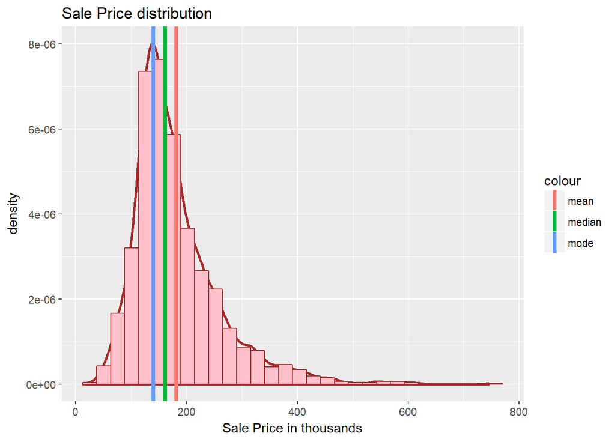

It looks like a unimodal right-skewed distribution. I will use its median and interquartile range as measures of center and variability for the further EDA as they are robust to outliers.

**Shapiro-Wilk normality test.**

```
##
##  Shapiro-Wilk normality test
##
## data:  train$SalePrice
## W = 0.87827, p-value < 2.2e-16
```

With the `p-val` < 2.2e-16 which is less than the significance level of 0.05 we reject the null hypothesis that the data is normally distributed. W = 0.87827. The closer w is to 1 the more likely it is that this distribution is normal.

**Testing for skewness.**

```r
skewness(train$SalePrice)
```

```
## [1] 1.70039
```

Positive skewness with the coefficient of 1.70039 > 1 indicates that the mean of the data values is larger than the median, and the data is extremely right-skewed.

For my future modeling I want my data to be as “normal” as possible. To address long-tailed distribution I will try log transformation.

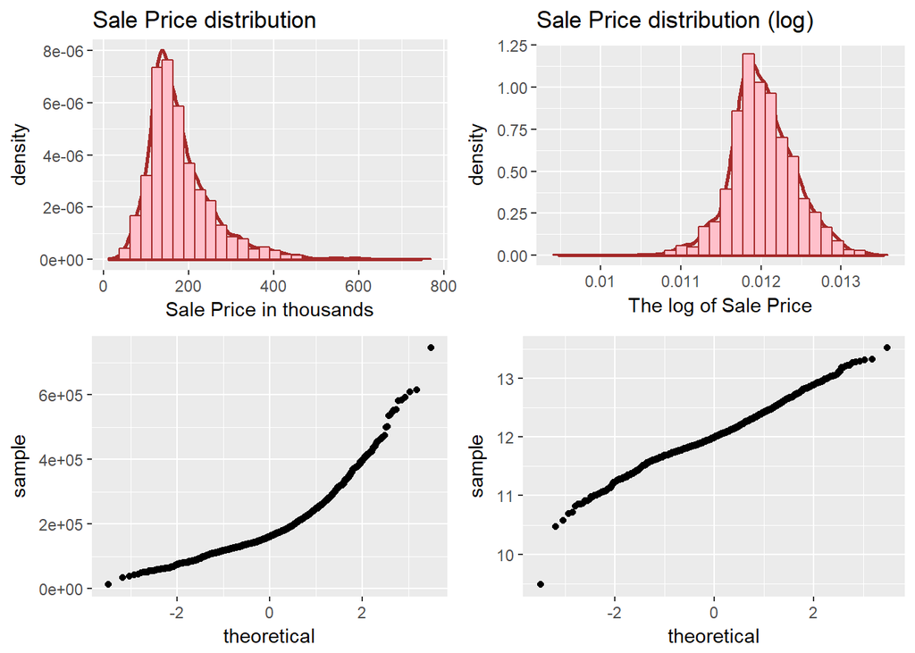

```
##
##  Shapiro-Wilk normality test
##
## data:  train$SalePrice
## W = 0.87827, p-value < 2.2e-16
```

```
##
##  Shapiro-Wilk normality test
##
## data:  log(train$SalePrice)
## W = 0.98782, p-value = 3.485e-12
```

According to the plots and Shapiro tests log transformation results in the more “normal” distribution. There is one very obvious outlier on the left side of the QQ plot of the logged Sale Price though which might affect the future model performance.

```
##
##  Grubbs test for one outlier
##
## data:  log(train$SalePrice)
## G = 6.30150, U = 0.98062, p-value = 2.489e-07
## alternative hypothesis: lowest value 9.48036750918924 is an outlier
```

With `p-value` equal to 2.489e-07 we reject the null hypothesis that this is not an outlier in favor to the alternative hypothesis that the lowest value of 9.48036750918924 is indeed an outlier. Since it is just one single value I am going to remove it from the train set for future modelling.

## 2.2 Multivariate analysis and understanding the structure of the data.

```
## Observations: 2,051
## Variables: 82
## $ Order           <int> 843, 2309, 1198, 2585, 2752, 134, 1545, 2609, ...
## $ PID             <int> 907175100, 526303060, 534250010, 535304020, 90...
## $ MS.SubClass     <int> 60, 20, 90, 20, 20, 20, 30, 80, 20, 70, 20, 20...
## $ MS.Zoning       <fctr> RL, RL, RL, RL, RL, RL, RM, RL, RL, RM, RL, R...
## $ Lot.Frontage    <int> 80, NA, 87, 66, 64, 78, 50, 83, 85, 59, NA, 65...
## $ Lot.Area        <int> 10400, 39384, 9246, 12778, 7488, 7800, 7000, 1...
## $ Street          <fctr> Pave, Pave, Pave, Pave, Pave, Pave, Pave, Pav...
## $ Alley           <fctr> NA, NA, NA, NA, NA, NA, NA, NA, NA, NA, NA, N...
## $ Lot.Shape       <fctr> Reg, IR1, IR1, Reg, IR1, Reg, Reg, Reg, Reg, ...
## $ Land.Contour    <fctr> Lvl, Low, Lvl, Lvl, Lvl, Lvl, Lvl, Lvl, Lvl, ...
## $ Utilities       <fctr> AllPub, AllPub, AllPub, AllPub, AllPub, AllPu...
## $ Lot.Config      <fctr> Corner, CulDSac, Inside, Inside, Inside, Insi...
## $ Land.Slope      <fctr> Gtl, Sev, Gtl, Gtl, Gtl, Gtl, Gtl, Gtl, Gtl, ...
```

[output cut: 69 more lines]

`MS.SubClass` identifies the type of dwelling involved in the sale, e.g. `"020"` stands for `"1-STORY 1946 & NEWER ALL STYLES"`, and therefore should will be converted into factor as well as `Overall.Qual` and `Overall.Cond`.

## 2.2.1 Numeric variables.

- **Identifying and visualizing numerical variables that are strongly correlated (-0.5 >cor.coef>0.5) with `SalePrice` excluding `Order`, `PID`, `Yr.Sold` and `Mo.Sold` variables.**

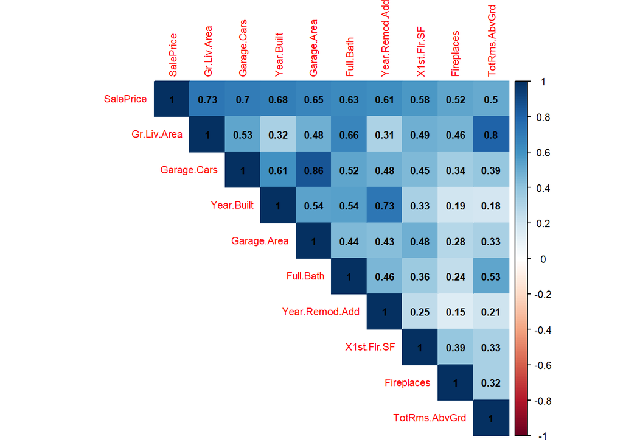

The plot indicates strongly correlated numerical variables as well as some obvious signs of multicollinearity (`Gr.Liv.Area`, `TotRms.AbvGrd`, `Garage.Cars` vs `Garage.Area`, etc.) which should be considered at the modelling stage.

- **SalePrice vs Gr.Liv.Area (*above ground living area square feet*) vs Sale.Condition.**

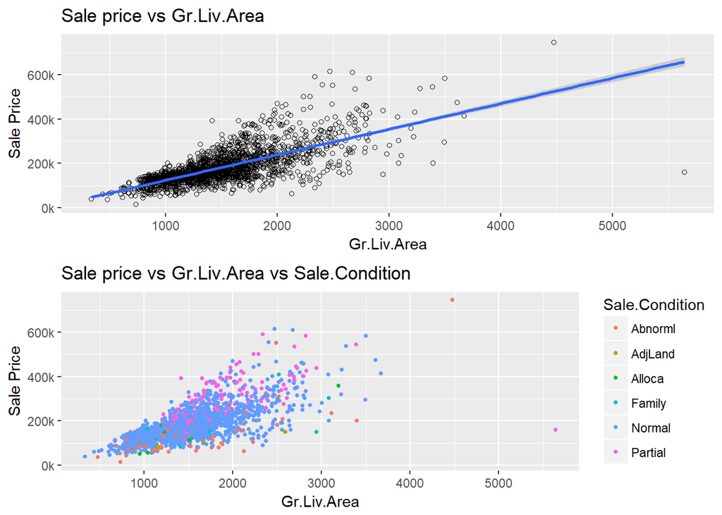

As per the first plot there are clearly at least two high leverage points. One of them with the living area larger than 5000 square feet was sold partially under $200 000 which might not represent true market values. The other one is just an unusual Abnormal condition sale.

A house sold under abnormal conditions often sells for much less than expected given its square footage. Similarly, a partial sale of a house results in a higher price on average holding constant square footage. Because houses with non-normal selling conditions exhibit atypical behavior and can disproportionately influence the model, I will only consider the properties sold under Normal Sale condition.

- **Garage.cars vs Garage.Area vs SalePrice.**

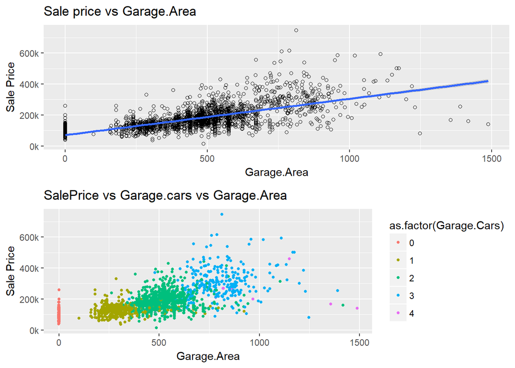

The plot shows strong linear relationship between `SalePrice` and garage variables as well as the presence of the outliers.

- **Year.Built and Year.Remod.Add vs Sale Price.**

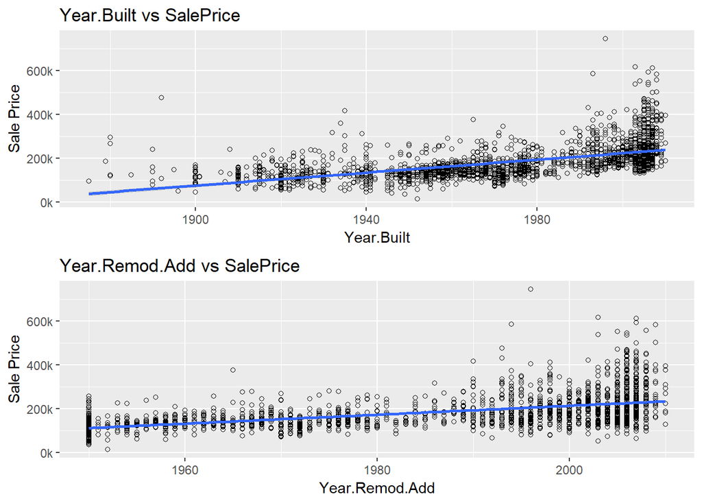

Even though the plot shows somewhat linear relationships between these variables and the price, we can never classify year directly as quantitative variable as we cannot perform calculations on it, therefore for my future modelling I will convert them into age variables.

- **Full bath and TotRms.AbvGrd vs SalePrice.**

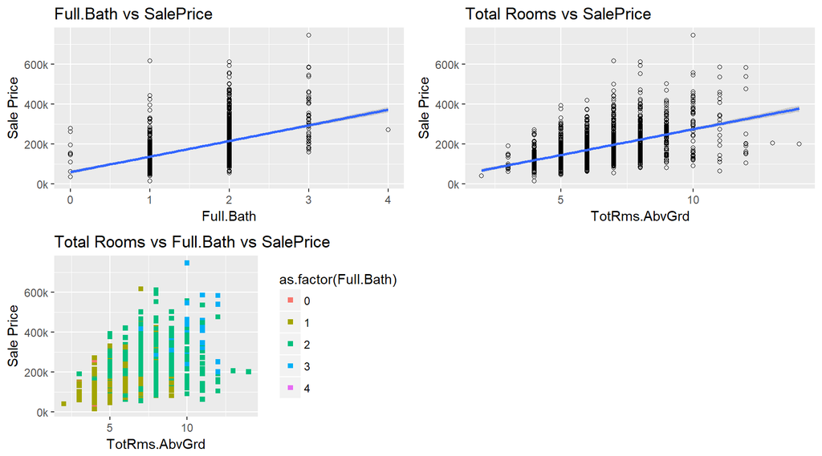

Apart from some very rare cases of having whether 0 or 4 bathrooms and/or 13-14 rooms the `SalePrice` seems to be quite dependent on the number of the bathrooms and total number of rooms which is an obvious indicator of the property size.

- **Gr.Liv.Area (*above ground living area*) and area of the 1st and 2nd floors (`X1st.Flr.SF`, `X2nd.Flr.SF`).**

```r
nrow(train[train$X2nd.Flr.SF+train$X1st.Flr.SF==train$Gr.Liv.Area ,])
```

```
## [1] 2023
```

```r
nrow(train)
```

```
## [1] 2051
```

We can see that 2023 out of 2051 properties have the sum of the first and the second floor equal to the above ground living area. In other words in 98.63% of the times the sum of `X1st.Flr.SF` and `X2nd.Flr.SF` is simply the `Gr.Liv.Area` therefore I am going to exclude the 1st and 2nd floor area variables from my future modelling as redundant.

## 2.2.2 Categorical variables analysis.

- **SalePrice vs. Neighborhood.**

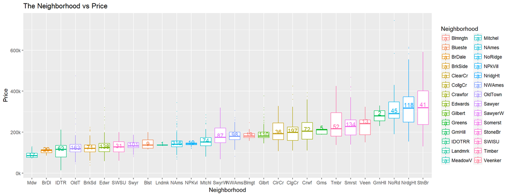

```
##    Neighborhood median.price Iqr.price counts
## 1       StoneBr     319900.0 164679.00     41
## 2       NridgHt     317250.0 123525.75    118
## 3       NoRidge     291000.0  80000.00     45
## 4       GrnHill     280000.0  50000.00      2
## 5       Veenker     241600.0  73000.00     13
## 6       Somerst     227777.5  74508.25    134
## 7        Timber     216794.5 114120.50     52
## 8        Greens     211500.0  23750.00      5
## 9       Crawfor     205000.0  82375.00     72
## 10      CollgCr     198500.0  66000.00    197
## 11      ClearCr     192500.0  81175.00     36
## 12      Blmngtn     181000.0  20100.50     19
## 13      Gilbert     181000.0  27036.25    110
## 14       NWAmes     179900.0  36625.00     98
## 15      SawyerW     175000.0  72337.50     87
## 16      Mitchel     152250.0  39937.50     74
## 17      NPkVill     143000.0   9300.00     19
## 18        NAmes     140750.0  29625.00    316
## 19      Blueste     137000.0  41500.00      9
## 20      Landmrk     137000.0      0.00      1
## 21       Sawyer     133500.0  25350.00    101
## 22        SWISU     128000.0  50500.00     31
## 23      Edwards     125000.0  41450.00    138
## 24      BrkSide     121600.0  33250.00     71
## 25      OldTown     119000.0  36600.00    163
## 26       IDOTRR     115750.0  57000.00     62
## 27       BrDale     111375.0  15275.00     20
## 28      MeadowV      85500.0  21000.00     17
```

- **Overall Quality and Overall Condition vs. SalePrice.**

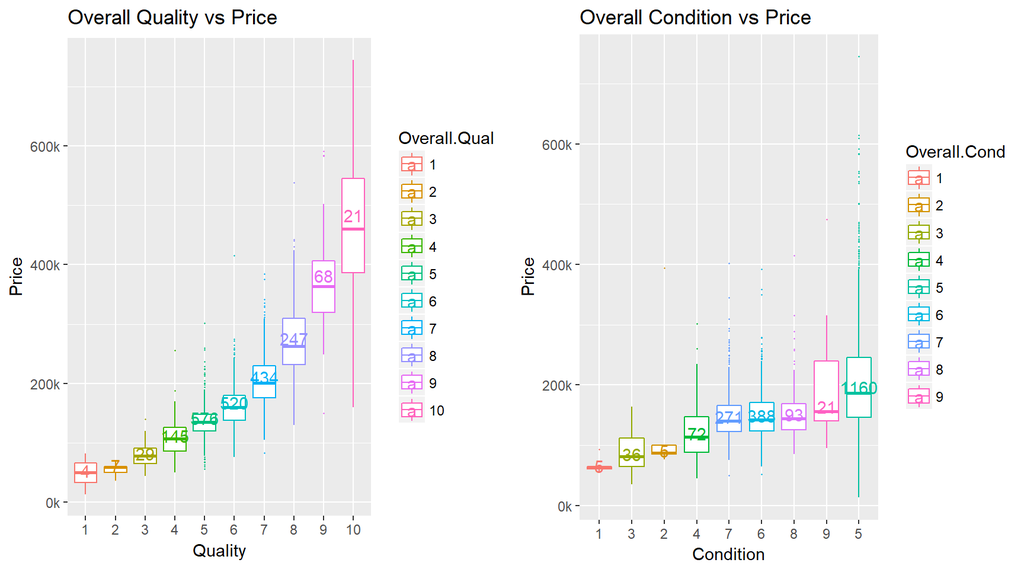

The box plot shows very strong relationship between `Overall Quality` and `Sale Price`. Not a big surprise since the quality of the property is one of the most important factors when buying. Whereas `Overall Condition` levels seem to be all over the place which indicates the presence of outliers. Levels 1 and 2 in either cases have very low number of observations which should be addressed in the feature engineering part.

- **The rest of the quality and condition variables.**

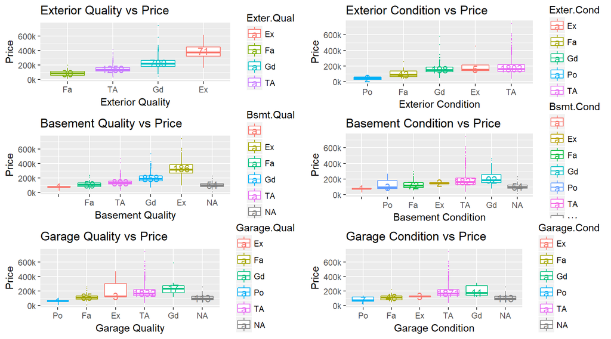

There´s definitely strong connection between `Exterior Quality` and `Basement Quality` vs `Sale Price`. The variables such as `Garage Quality`, `Basement Condition`, `Exterior condition` and `Garage Condition` are mostly represented by “TA” (“average”) level and have very low variances.

- **Conclusion.**
- As our response variable, `SalePrice`, is continuous, I will be implementing regression models. One assumption of linear regression models is that the error between the observed and expected values (i.e., the residuals) should be normally distributed. `SalePrice` has a right skew, so log transformation of the response variable should be considered since it results in its distribution being more “normal”.
- Among numeric variables the most highly correlated to the `SalePrice` are `Gr.Liv.Area`, `Garage.Cars`, `Garage.Area`, `Year.Built`, `Full.Bath`, `Year.Remod.Add`, `X1st.Flr.SF`, `Fireplaces`, `TotRms.AbvGrd`. There are also signs of high correlations among some of the predictors.
- The three “year” variables: `Year.Built`, `Year.Remod.Add` and `Garage.Yr.Blt` that can´t be treated directly as quantitative variables and need further transformation.
- As a result of EDA I found out that this data set contains categorical variables that have extremely low variances, i.e. for most of the observations in data set there is only one level meaning that there is very little information in these variables because they mostly consist of a single level (e.g. “TA” in the cases of `Garage Quality`, `Garage Condition`. etc.).
- There are also factors that have levels with very few observations within the levels (e.g. “Landmark” level in the case of `Neighborhood`, etc.). These levels have minimal chance of making a real impact on model fit.

## 3. Handling missing values (full data set).

```r
data_full<-rbind(train, test)
```

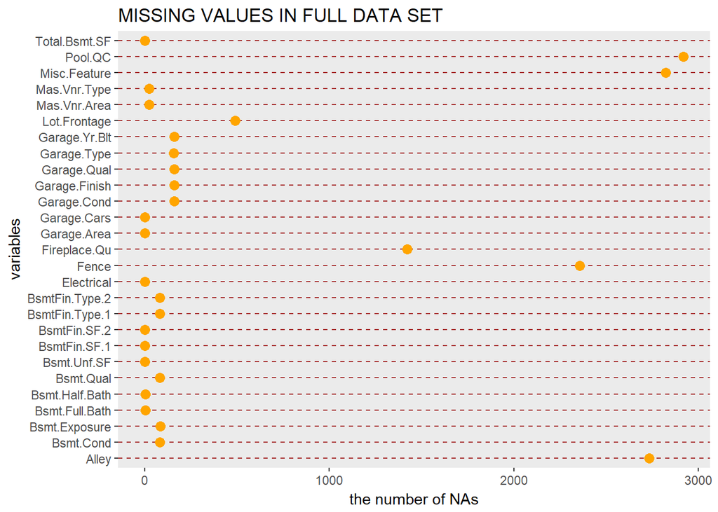

According to [Dataset description file](https://github.com/poziryna84/Kschool_Final_Project/blob/master/DataSet_Description.RMD) `NA` stands for “no feature” for 14 following variables:

- **Pool.QC**
- **Misc.Feature**
- **Alley**
- **Fence**
- **Fireplace.Qu**
- **Garage.Type**
- **Garage.Qual**
- **Garage.Finish**
- **Garage.Cond**
- **BsmtFin.Type.1**
- **BsmtFin.Type.2**
- **Bsmt.Qual**
- **Bsmt.Cond**
- **Bsmt.Exposure**

In these cases `NA` will be set to “No_ftr” (no feature).

- **The rest of the `NAs`**

`LotFrontage` means the portion of a lot that abuts a public or private street. There are 490 NAs which will replaced with its median value.

## 4. Feature engeneering part.

## 4.1 Identifying and dropping unused factors levels.

Before dealing with level transformations I will identify and drop unused levels in the following categorical variables:

```
##  [1] "Mas.Vnr.Type"   "Bsmt.Qual"      "Bsmt.Cond"      "Bsmt.Exposure"
##  [5] "BsmtFin.Type.1" "BsmtFin.Type.2" "Electrical"     "Garage.Finish"
##  [9] "Garage.Qual"    "Garage.Cond"
```

## 4.2. Combining levels.

To avoid redundant levels in categorical variables and to deal with rare levels I am going to combine them.

- **Neighborhood levels combination**.

To avoid having too many levels and/or too few cases within the `Neighborhood` levels I am going to combine them and create a new variable called `New_Neighborhood` by considering the average value of the `SalePrice` of each level.

**Neighborhood levels**

```
##
## Blmngtn Blueste  BrDale BrkSide ClearCr CollgCr Crawfor Edwards Gilbert
##      28      10      30     108      44     267     103     194     165
##  Greens GrnHill  IDOTRR Landmrk MeadowV Mitchel   NAmes NoRidge NPkVill
##       8       2      93       1      37     114     443      71      23
## NridgHt  NWAmes OldTown  Sawyer SawyerW Somerst StoneBr   SWISU  Timber
##     166     131     239     151     125     182      51      48      72
## Veenker
##      24
```

*Suggest_levels()* function from *regclass* package determines levels that are similar to each other in terms of their average value of `SalePrice`.

The target number of 5 neighborhoods was identified after several iterations as it allows us to have a decent number of cases within each level.

```r
f<-suggest_levels(SalePrice~Neighborhood,data=data_full,target=5,recode=TRUE)
```

```
## 5 target clusters: (MeadowV&IDOTRR&BrDale)(OldTown&BrkSide&Edwards&SWISU&Sawyer&Landmrk&NPkVill&Blueste&NAmes)(Mitchel&SawyerW&NWAmes&Gilbert&Greens&Blmngtn&CollgCr&Crawfor&ClearCr)(Somerst&Timber&Veenker&GrnHill)(NridgHt&StoneBr&NoRidge)
```

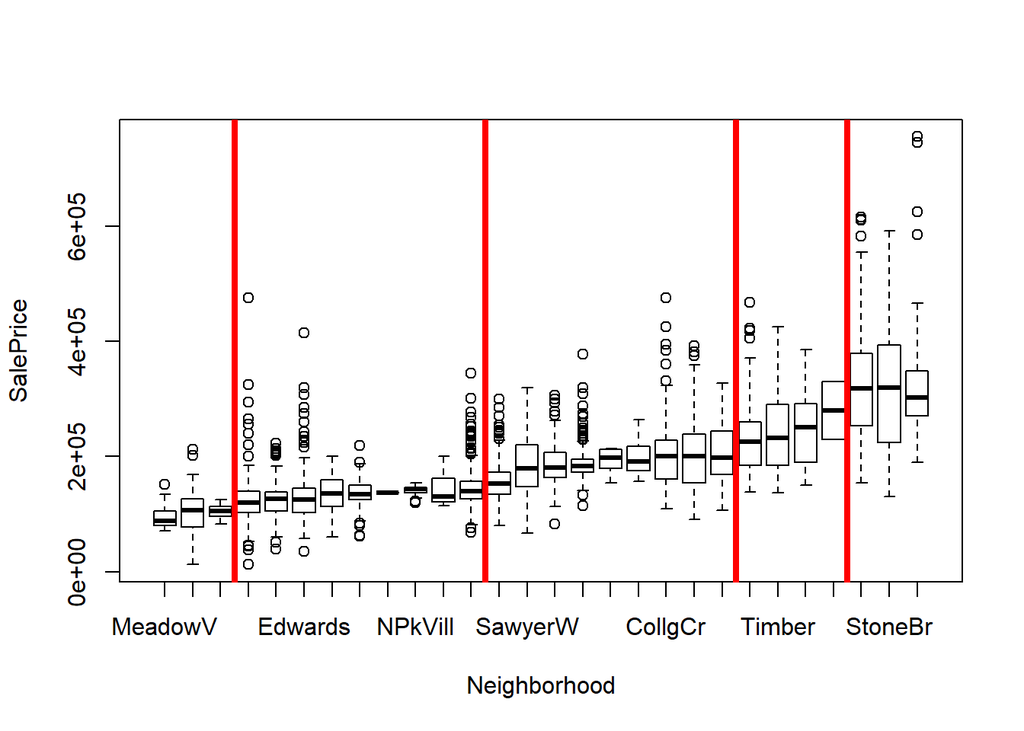

The new levels are A, B, C , E as follows:

```
##        Old New
## 1   BrDale   A
## 2   IDOTRR   A
## 3  MeadowV   A
## 4  Blueste   B
## 5  BrkSide   B
## 6  Edwards   B
## 7  Landmrk   B
## 8    NAmes   B
## 9  NPkVill   B
## 10 OldTown   B
## 11  Sawyer   B
## 12   SWISU   B
## 13 Blmngtn   C
## 14 ClearCr   C
## 15 CollgCr   C
## 16 Crawfor   C
## 17 Gilbert   C
## 18  Greens   C
## 19 Mitchel   C
## 20  NWAmes   C
## 21 SawyerW   C
## 22 GrnHill   D
## 23 Somerst   D
## 24  Timber   D
## 25 Veenker   D
## 26 NoRidge   E
## 27 NridgHt   E
## 28 StoneBr   E
```

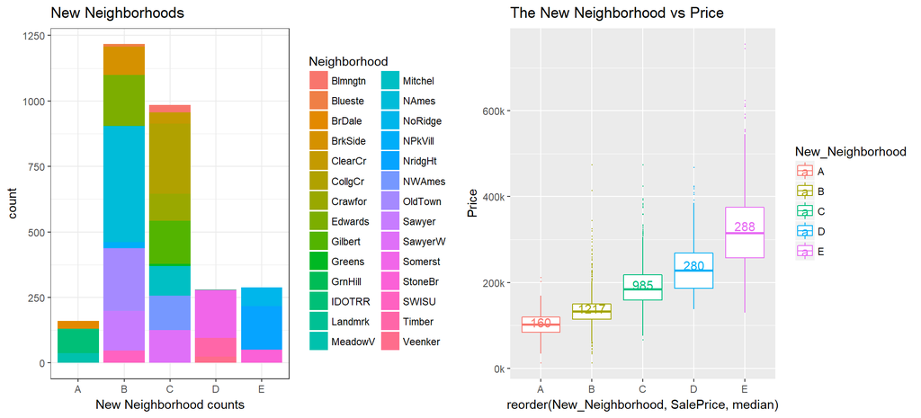

```
##
##    A    B    C    D    E
##  160 1217  985  280  288
```

`New_Neighbourhood` variable has been created with the minimum number of observations within its levels being 160.

**Overall Condition and Overall Quality modifications.**

Regarding overall condition and quality variables it also makes sense to combine similar levels but this time based on their orderings.

**Overall Condition levels**

```
##
##    1    2    3    4    5    6    7    8    9
##    7   10   50  101 1654  533  390  144   41
```

**Overall Quality levels**

```
##
##   1   2   3   4   5   6   7   8   9  10
##   4  13  40 226 825 732 602 350 107  31
```

`Overall.Qual` and `Overall.Qual` variable levels will be transformed as follows:

- **10** *very Excellent* as **exc**
- **9** *excellent* as **exc**
- **8** *very good* as **exc**
- **7** *good* as **good**
- **6** *above average* as **good**
- **5** *average* as **avg**
- **4** *below average* as **blw_avg**
- **3** *fair* as **blw_avg**
- **2** *poor* as **blw_avg**
- **1** *very poor* as **blw_avg**

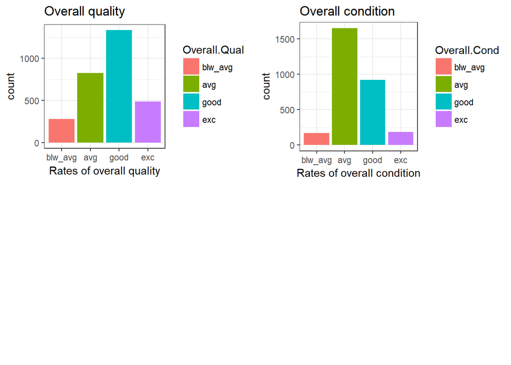

- Modified `Overall.Cond`.

```
##
## blw_avg     avg    good     exc
##     168    1654     923     185
```

- Modified `Overall.Qual`.

```
##
## blw_avg     avg    good     exc
##     283     825    1334     488
```

We can observe more sensible distribution as a result of having fewer levels.

**Other quality and condition variables levels combinations.**

Since all the other quality and condition variables also have a clear ordering and share the same legend it makes sense to modify them together as shown below:

- **Fa** *fair* and **Po** *poor* as **blw_avg**
- **TA** *avarage* as **avg**
- **Ex** *excellent* and **Gd** *good* as **abv_avg**
- **No_ftr** as **No_ftr**

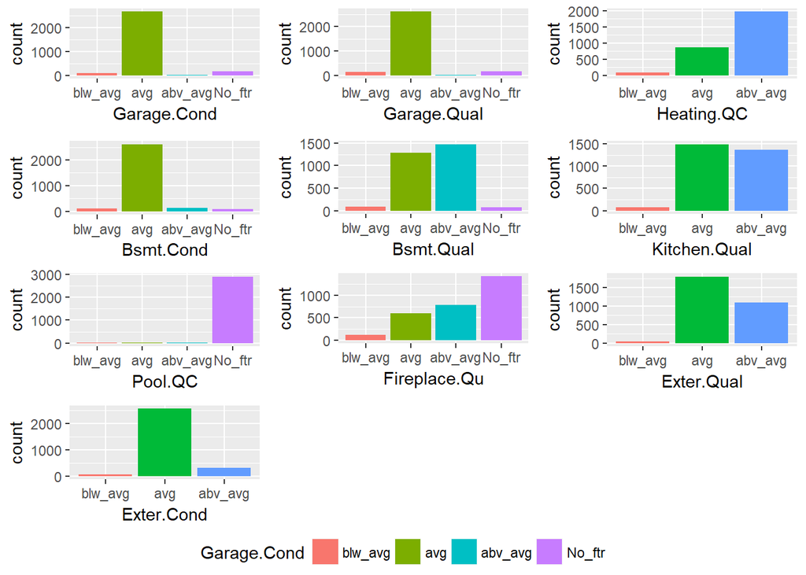

Some variables such as `Pool.QC`, `Bsmt.Cond`, `Exter.Cond`, etc. have extremely low variances, but I will leave it to the feature selection and dimensionality reduction stages.

- **The rest of the categorical variables.**

To combine levels using their frequency, we first look at the frequency distribution of each level and reset the levels that have frequency of less than 5% of total observation into **“Other”** level. The variables to consider are:

```
##  [1] "MS.SubClass"    "MS.Zoning"      "Street"         "Alley"
##  [5] "Lot.Shape"      "Land.Contour"   "Utilities"      "Lot.Config"
##  [9] "Land.Slope"     "Condition.1"    "Condition.2"    "Bldg.Type"
## [13] "House.Style"    "Roof.Style"     "Roof.Matl"      "Exterior.1st"
## [17] "Exterior.2nd"   "Mas.Vnr.Type"   "Foundation"     "Bsmt.Exposure"
## [21] "BsmtFin.Type.1" "BsmtFin.Type.2" "Heating"        "Electrical"
## [25] "Functional"     "Garage.Type"    "Paved.Drive"    "Fence"
## [29] "Misc.Feature"   "Sale.Type"
```